# Differential gene expression using EBSeq

Dave Tang

2020-09-07

R code from vignette source [EBSeq_Vignette](https://www.bioconductor.org/packages/release/bioc/vignettes/EBSeq/inst/doc/EBSeq_Vignette.R).

```r
if (!"EBSeq" %in% installed.packages()[, "Package"]){
  BiocManager::install("EBSeq")
}
library(EBSeq)
```

## Gene level differential expression

Workflow: Expression matrix -> `MedianNorm` -> define `cond` -> `EBTest` -> `GetDEResults`.

Load example data with 1000 genes across 10 samples. These values should exhibit raw counts, without normalisation across samples.

```r
data(GeneMat)
head(GeneMat)
```

```
##        [,1] [,2] [,3] [,4] [,5] [,6] [,7]  [,8] [,9] [,10]
## Gene_1 1879 2734 2369 2636 2188 9743 9932 10099 9829  9831
## Gene_2   24   40   22   27   31  118  108   144  117   113
## Gene_3 3291 3259 3214 3407 3298 1058  960   679  605   662
## Gene_4   97  124  146  114  126   33   19    31   22    36
## Gene_5  485  485  469  428  475  128  135   103  118   110
## Gene_6  113   92   64   96  137   39   16    23   30    16
```

Median normalisation.

```r
Sizes <- MedianNorm(GeneMat)
Sizes
```

```
##  [1] 1.0092334 1.0025114 1.0088298 1.0084447 1.0092992 1.0033437 0.9964052
##  [8] 0.9979051 1.0014176 1.0083016
```

Run `EBTest` where `maxround` is the number of iterations. The default value is 5 but users should always check the convergence (check difference in values between each iteration) by looking at the Alpha and Beta in output. If the hyper-parameter estimations are not converged in 5 iterations, larger number is suggested.

```r
cond <- as.factor(rep(c("C1","C2"), each=5))

EBOut <- EBTest(Data = GeneMat,
                Conditions = cond,
                sizeFactors = Sizes,
                maxround = 5)

EBOut$Alpha
```

```
##            [,1]
## iter1 0.8101264
## iter2 0.8076690
## iter3 0.8071266
## iter4 0.8074156
## iter5 0.8065706
```

```r
EBOut$Beta
```

```
##            Ng1
## iter1 1.569830
## iter2 1.580238
## iter3 1.577823
## iter4 1.579587
## iter5 1.575817
```

`GetDEResults` will obtain differential expression analysis results in a two-condition test. List will contain:

- DEfound - A list of DE transcripts.
- PPMat - Posterior probability matrix. Transcripts are following the same order as in the input matrix. Transcripts that were filtered by magnitude (in EBTest function), FC, or FCR are assigned with NA for both PPDE and PPEE.
- Status - Each transcript will be assigned with one of the following values: “DE”, “EE”, “Filtered: Low Expression”, “Filtered: Fold Change” and “Filtered: Fold Change Ratio”. Transcripts are following the same order as in the input matrix.

```r
EBDERes <- GetDEResults(EBOut, FDR=0.05)

EBDERes$PPMat %>%
  as.data.frame() %>%
  rownames_to_column(var = "id") %>%
  filter(PPDE > 0.95) %>%
  pull(id) -> test

identical(test, EBDERes$DEfound)
```

```
## [1] TRUE
```

Differential expression status.

```r
table(EBDERes$Status)
```

```
##
##                    DE                    EE Filtered: Fold Change
##                    95                   902                     3
```

## Isoform level differential expression

Workflow: Expression matrix -> `MedianNorm` -> `GetNg` -> `IsoformNgTrun` -> define `cond` -> `EBTest` -> `GetDEResults`.

Example transcript/isoform data is a list with three items:

- `IsoMat` - expression matrix
- `IsoNames` - transcript IDs
- `IsosGeneNames` - gene IDs

```r
data(IsoList)

IsoMat <- IsoList$IsoMat
head(IsoMat)
```

```
##         [,1] [,2] [,3] [,4] [,5] [,6] [,7] [,8] [,9] [,10]
## Iso_1_1  176  212  164  142  180  687  681  737  446   527
## Iso_1_2  789  915  919  942  892 3334 3211 2641 3371  3382
## Iso_1_3 1300 1377 1408 1376 1395  383  440  367  378   369
## Iso_1_4  474  487  483  473  499 1587 1671 1437 1598  1668
## Iso_1_5 1061  949  816 1040  897  211  266  289  231   275
## Iso_1_6  346  348  426  392  488 1452 1751 1487 1310  1370
```

```r
IsoNames <- IsoList$IsoNames
length(unique(IsoNames))
```

```
## [1] 1200
```

```r
IsosGeneNames <- IsoList$IsosGeneNames
length(unique(IsosGeneNames))
```

```
## [1] 600
```

Median normalisation on expression matrix.

```r
IsoSizes <- MedianNorm(IsoMat)
```

Fit on isoform level. `GetNg` generates the Ng vector for the isoform level data, while using the number of isoform in the host gene to define the uncertainty groups.

```r
NgList <- GetNg(IsoNames, IsosGeneNames)
IsoNgTrun <- NgList$IsoformNgTrun
IsoNgTrun[c(1:3,201:203,601:603)]
```

```
## Iso_1_1 Iso_1_2 Iso_1_3 Iso_2_1 Iso_2_2 Iso_2_3 Iso_3_1 Iso_3_2 Iso_3_3
##       1       1       1       2       2       2       3       3       3
```

DE results for isoforms.

```r
cond <- as.factor(rep(c("C1","C2"), each=5))
IsoEBOut <- EBTest(Data = IsoMat,
                   NgVector = IsoNgTrun,
                   Conditions <- cond,
                   sizeFactors = IsoSizes,
                   maxround = 5)

IsoEBDERes <- GetDEResults(IsoEBOut, FDR=0.05)

length(IsoEBDERes$DEfound)
```

```
## [1] 104
```

```r
IsoEBDERes$PPMat %>%
  as.data.frame() %>%
  rownames_to_column(var = "id") %>%
  filter(PPDE > 0.95) %>%
  nrow()
```

```
## [1] 104
```

## No replicates

When replicates are not available, it is difficult to estimate the transcript specific variance. In this case, EBSeq estimates the variance by pooling similar genes together. Specifically, we take genes with FC in the 25% - 75% quantile of all FC’s as candidate genes. By defining `NumBin` = 1000 (default), EBSeq will group genes with similar means into 1,000 bins. For each candidate gene, we use the across-condition variance estimate as its variance estimate. For each bin, the bin-wise variance estimation is taken to be the median of the across-condition variance estimates of the candidate genes within that bin. For each non-candidate gene, we use the bin-wise variance estimate of the host bin (the bin containing this gene) as its variance estimate. This approach works well when there are no more than 50% DE genes in the data set.

Workflow: Expression matrix -> `MedianNorm` -> define `cond` -> `EBTest` -> `GetDEResults` -> `PostFC`.

On gene level. Use `PostFC` to calculate the posterior fold change for each transcript across conditions.

```r
data(GeneMat)
GeneMat.norep <- GeneMat[,c(1,6)]
Sizes.norep <- MedianNorm(GeneMat.norep)
EBOut.norep <- EBTest(Data = GeneMat.norep,
                      Conditions = as.factor(rep(c("C1","C2"))),
                      sizeFactors = Sizes.norep,
                      maxround=5)
```

```
## Removing transcripts with 100 th quantile < = 0
## 999 transcripts will be tested
```

```r
EBDERes.norep <- GetDEResults(EBOut.norep)
GeneFC.norep <- PostFC(EBOut.norep)

length(EBDERes.norep$DEfound)
```

```
## [1] 122
```

On isoform level. Workflow: Expression matrix -> `MedianNorm` -> `GetNg` -> `IsoformNgTrun` -> define `cond` -> `EBTest` -> `GetDEResults` -> `PostFC`.

```r
data(IsoList)
IsoMat <- IsoList$IsoMat
IsoNames <- IsoList$IsoNames
IsosGeneNames <- IsoList$IsosGeneNames

IsoMat.norep <- IsoMat[,c(1,6)]
IsoSizes.norep <- MedianNorm(IsoMat.norep)

NgList <- GetNg(IsoNames, IsosGeneNames)
IsoNgTrun <- NgList$IsoformNgTrun
IsoEBOut.norep <- EBTest(Data = IsoMat.norep,
                         NgVector = IsoNgTrun,
                         Conditions = as.factor(c("C1","C2")),
                         sizeFactors = IsoSizes.norep,
                         maxround = 5)
```

```
## Removing transcripts with 100 th quantile < = 0
## 1192 transcripts will be tested
```

```r
IsoEBDERes.norep <- GetDEResults(IsoEBOut.norep)

IsoFC.norep <- PostFC(IsoEBOut.norep)
```

Create result table and plot.

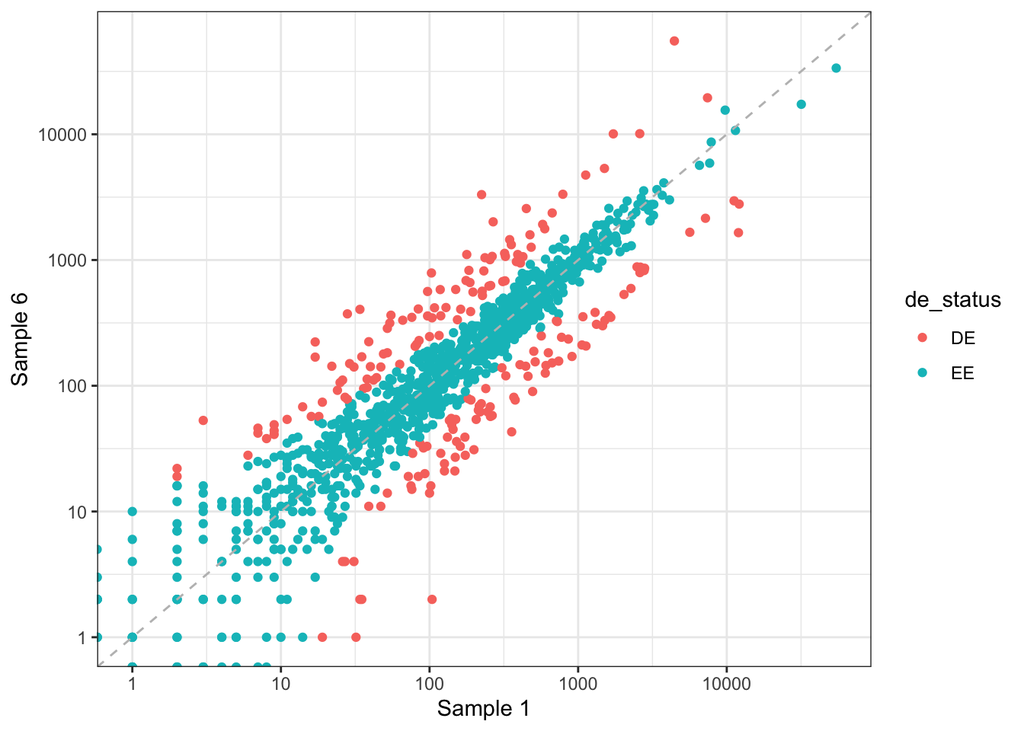

```r
status_df <- data.frame(id = names(IsoEBDERes.norep$Status),
                        de_status = IsoEBDERes.norep$Status)

fc_df <- data.frame(id = names(IsoFC.norep$PostFC),
                    fc = IsoFC.norep$PostFC)

exp_df <- data.frame(IsoMat[, c(1, 6)])
exp_df$mean_exp <- rowMeans(exp_df)
exp_df$id <- row.names(IsoMat[, c(1, 6)])

de_test_df <- data.frame(IsoEBDERes.norep$PPMat)
de_test_df$id <- row.names(IsoEBDERes.norep$PPMat)

inner_join(x = exp_df, y = fc_df, by = "id") %>%
  inner_join(., y = de_test_df, by = "id") %>%
  inner_join(., y = status_df, by = "id") %>%
  filter(!grepl(pattern = "Filtered", x = de_status)) %>%
  select(id, fc, PPEE, PPDE, everything()) -> my_df

ggplot(my_df, aes(X1, X2, colour = de_status)) +
  geom_point() +
  geom_abline(slope = 1, lty = 2, colour = "grey") +
  scale_x_log10() +
  scale_y_log10() +
  theme_bw() +
  labs(x = "Sample 1", y = "Sample 6") +
  NULL
```

As a function.

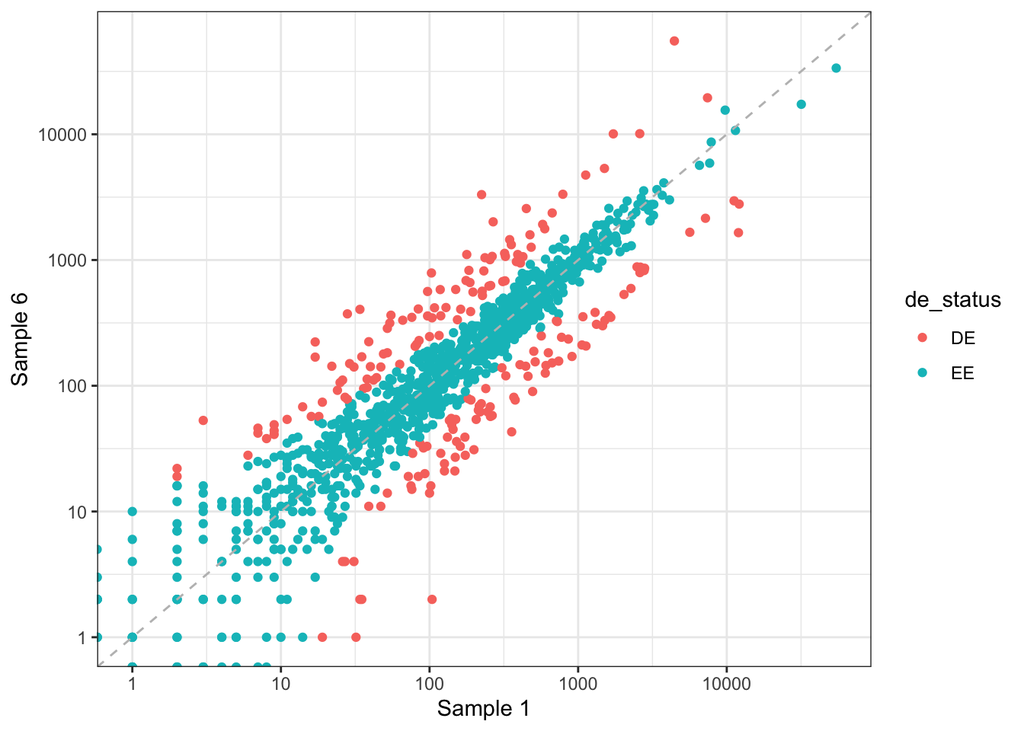

```r
plot_ebtest_norep <- function(my_mat, my_ebtest, my_fc, my_xlab, my_ylab){
  exp_df <- data.frame(my_mat)
  exp_df$mean_exp <- rowMeans(exp_df)
  exp_df$id <- row.names(my_mat)

  status_df <- data.frame(id = names(my_ebtest$Status),
                          de_status = my_ebtest$Status)

  de_test_df <- data.frame(my_ebtest$PPMat)
  de_test_df$id <- row.names(my_ebtest$PPMat)

  fc_df <- data.frame(id = names(my_fc$PostFC),
                      fc = my_fc$PostFC)

  inner_join(x = exp_df, y = fc_df, by = "id") %>%
    inner_join(., y = de_test_df, by = "id") %>%
    inner_join(., y = status_df, by = "id") %>%
    filter(!grepl(pattern = "Filtered", x = de_status)) %>%
    select(id, fc, PPEE, PPDE, everything()) -> my_df

  ggplot(my_df, aes(X1, X2, colour = de_status)) +
    geom_point() +
    geom_abline(slope = 1, lty = 2, colour = "grey") +
    scale_x_log10() +
    scale_y_log10() +
    theme_bw() +
    labs(x = my_xlab, y = my_ylab) +
    NULL -> p

  print(p)
}

plot_ebtest_norep(IsoMat[, c(1, 6)], IsoEBDERes.norep, IsoFC.norep, "Sample 1", "Sample 6")
```

## RSEM

We will use `tximport` to load RSEM results. Install if missing and then load library.

```r
if (!"tximport" %in% installed.packages()[, "Package"]){
  BiocManager::install("tximport")
}
library(tximport)
```

Load RSEM results.

```r
get_file_list <- function(pattern = ".rsem.genes.results.gz", result_dir = "../star_rsem/"){
  my_list <- list.files(path = result_dir, pattern = pattern, full.names = TRUE, recursive = TRUE)
  my_sample <- sub(pattern = pattern, replacement = "", x = basename(my_list))
  my_sample <- gsub(pattern = "-", replacement = "_", x = my_sample)
  names(my_list) <- my_sample
  return(my_list)
}

rsem_gene_file <- get_file_list(pattern = "_chrX.*rsem.genes.results.gz")
rsem_tran_file <- get_file_list(pattern = "_chrX.*rsem.isoforms.results.gz")

rsem_gene <- tximport(rsem_gene_file,
                      type = "rsem",
                      txIn = FALSE,
                      txOut = FALSE)

rsem_tran <- tximport(rsem_tran_file,
                      type = "rsem",
                      txIn = TRUE,
                      txOut = TRUE)

dim(rsem_gene$counts)
```

```
## [1] 2082   12
```

```r
dim(rsem_tran$counts)
```

```
## [1] 2343   12
```

Load phenotype data.

```r
pheno_data <- read_csv(file = "../raw/chrX_data/geuvadis_phenodata.csv")
pheno_data
```

```
## # A tibble: 12 x 3
##    ids       sex    population
##    <chr>     <chr>  <chr>
##  1 ERR188044 male   YRI
##  2 ERR188104 male   YRI
##  3 ERR188234 female YRI
##  4 ERR188245 female GBR
##  5 ERR188257 male   GBR
##  6 ERR188273 female YRI
##  7 ERR188337 female GBR
##  8 ERR188383 male   GBR
##  9 ERR188401 male   GBR
## 10 ERR188428 female GBR
## 11 ERR188454 male   YRI
## 12 ERR204916 female YRI
```

Define condition.

```r
my_cond <- factor(pheno_data$sex[match(colnames(rsem_gene$counts), pheno_data$ids)])
my_cond
```

```
##  [1] male   male   female female male   female female male   male   female
## [11] male   female
## Levels: female male
```

Differential expression analysis.

```r
rsem_gene_ebtest <- EBTest(Data = rsem_gene$counts,
                           Conditions = my_cond,
                           sizeFactors = MedianNorm(rsem_gene$counts),
                           maxround = 5)
```

```
## Removing transcripts with 100 th quantile < = 0
## 1443 transcripts will be tested
```

```r
rsem_gene_de <- GetDEResults(rsem_gene_ebtest)
rsem_gene_fc <- PostFC(rsem_gene_ebtest)

rsem_gene_de$DEfound
```

```
##  [1] "NM_001007" "NM_004187" "NM_004650" "NM_005044" "NM_005089" "NM_005676"
##  [7] "NM_006306" "NM_012080" "NM_145799" "NR_001564"
```

Load `rtracklayer` and install if necessary.

```r
if (!"rtracklayer" %in% installed.packages()[, "Package"]){
  BiocManager::install("rtracklayer")
}
library(rtracklayer)
```

Load GTF file.

```r
my_gtf <- import(con = "../raw/chrX_data/genes/chrX.gtf")
length(unique(my_gtf$gene_id))
```

```
## [1] 2082
```

```r
length(unique(my_gtf$transcript_id))
```

```
## [1] 2343
```

Differentially expression gene names.

```r
unique(my_gtf[my_gtf$gene_id %in% rsem_gene_de$DEfound, ]$gene_name)
```

```
##  [1] "RBM10"  "PRKX"   "PUDP"   "KDM5C"  "SEPT6"  "PNPLA4" "ZRSR2"  "SMC1A"
##  [9] "RPS4X"  "XIST"
```

For transcripts we need to create `IsoNames`. Recall that we need:

1. IsoMat <- IsoList$IsoMat
2. IsoNames <- IsoList$IsoNames
3. IsosGeneNames <- IsoList$IsosGeneNames

Workflow: Expression matrix -> `MedianNorm` -> `GetNg` -> `IsoformNgTrun` -> define `cond` -> `EBTest` -> `GetDEResults` -> `PostFC`.

```r
my_mat <- rsem_tran$counts
my_iso <- row.names(rsem_tran$counts)
my_gtf_matched <- my_gtf[match(my_iso, my_gtf$transcript_id), ]
my_iso_gene <- my_gtf_matched$gene_id

rsem_tran_ebtest <- EBTest(Data = my_mat,
                           NgVector = GetNg(my_iso, my_iso_gene)$IsoformNgTrun,
                           Conditions = my_cond,
                           sizeFactors = MedianNorm(my_mat),
                           maxround = 5)
```

```
## Removing transcripts with 100 th quantile < = 0
## 1509 transcripts will be tested
```

```r
rsem_tran_de <- GetDEResults(rsem_tran_ebtest)
rsem_tran_fc <- PostFC(rsem_tran_ebtest)

rsem_tran_de$DEfound
```

```
##  [1] "NM_001007" "NM_004187" "NM_004650" "NM_005044" "NM_005089" "NM_005676"
##  [7] "NM_006306" "NM_012080" "NM_145799" "NR_001564"
```